# Kirsten’s Week 8 Code-Along Verion (Multiple Linear Regression

Kirsten Hodgson

11/28/2020

### 1. Overview

In this week’s lab, we are going to perform, assess, interpret, and communicate outcomes from multiple linear regression using the **penguins** data from the `palmerpenguins` package.

### 2. Set-up

See set-up chunk for required packages, etc.

### 3. Explore the **penguins** data

#### a. Initial exploration

We have a number of functions that can help take a quick look at our data, including:

- `View(penguins)` to view the entire data frame - remember to do this in the **Console** instead of as a stored code in your .Rmd
- `head(penguins)` to look at the first 6 lines
- `names(penguins)` to see the variable names
- `summary(penguins)` to get a summary by variable

Run the above functions in the Console to remind yourself of the structure, organization, and variables in the **penguins** data.

#### b. Pairs plots with `GGally`

Now, we’ll do some multivariate exploration using a new package, `GGally`

**“Out-of-the-box” (includes all variables):**

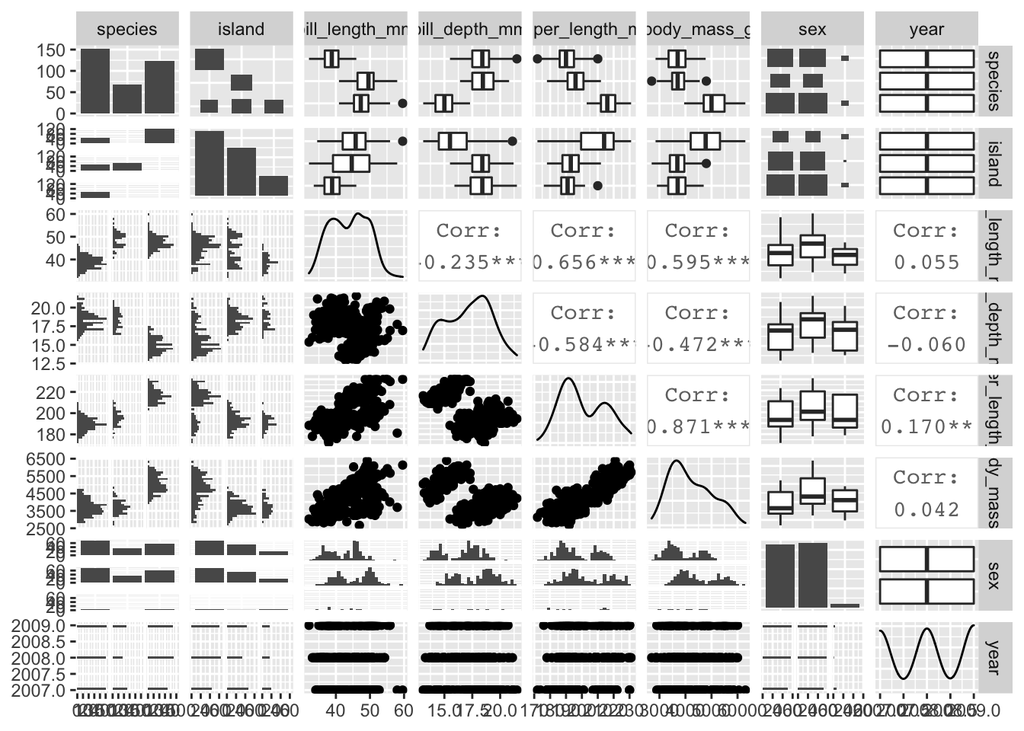

```r
ggpairs(penguins)
```

That is **WAY** too much. To narrow it down a bit (for example only the continuous variables, which are the variables we’re usually most concerned about linearity between re:assumptions), we can select just `species` and the four continuous variables (`bill_length_mm` through `body_mass_g` in the data frame), then pipe right into `ggpairs()`, updating aesthetics within it like we would in `ggplot()`:

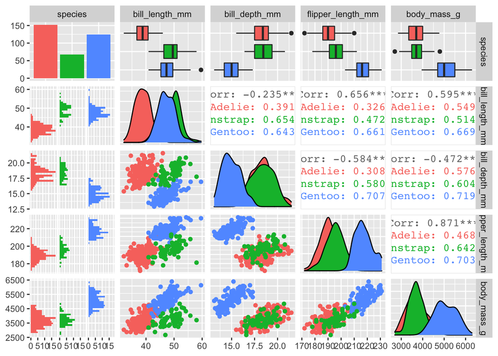

```r
penguins %>%
  select(species, bill_length_mm:body_mass_g) %>%
  ggpairs(aes(color = species))
```

The resulting matrix gives us a LOT of information about distributions within groups (the histograms in column 1, boxplots in row 1, and density plots along the diagonal), and relationships (the scatterplots below the diagonal, and the correlation values above the diagonal).

Most importantly, it looks like there aren’t any notable **non-linear** relationships existing within species between any of the continuous variables (in the scatterplots).

Could we make each of these graphs separately with `ggplot2` to consider relationships? Sure! But `GGally` makes it quite a bit easier for us by automating it.

### 4. Multiple linear regression

#### a. Build your model

Recall: some of the assumptions of linear regression (e.g. heteroscedasticity and normality of residuals) are diagnosed *after* the model is created.

So our next step is to do multiple linear regression. Recall, the general code structure (without interaction terms) is:

`model_name <- lm(dv ~ iv1 + iv2 + iv3 + ..., data = df_name)`

In this example, we will model **penguin mass** to see how it changes with respect to three predictor variables: **flipper length, penguin species,** and **penguin sex**. Are there other possible models to explore? Absolutely, and in the real world you may want to try them out and compare. For today, we’ll just consider that one model.

Insert a new code chunk, and build your model:

```r
penguin_lm <- lm(body_mass_g ~ flipper_length_mm + species + sex, data = penguins)
```

#### b. Take a look at the result

View the outputs by running `summary(penguin_lm)`:

```r
summary(penguin_lm)
```

```
##
## Call:
## lm(formula = body_mass_g ~ flipper_length_mm + species + sex,
##     data = penguins)
##
## Residuals:
##    Min     1Q Median     3Q    Max
## -721.8 -195.7   -5.9  198.6  873.7
##
## Coefficients:
##                   Estimate Std. Error t value Pr(>|t|)
## (Intercept)       -365.817    532.050  -0.688   0.4922
## flipper_length_mm   20.025      2.846   7.037 1.15e-11 ***
## speciesChinstrap   -87.634     46.347  -1.891   0.0595 .
## speciesGentoo      836.260     85.185   9.817  < 2e-16 ***
## sexmale            530.381     37.810  14.027  < 2e-16 ***
## ---
## Signif. codes:  0 '***' 0.001 '**' 0.01 '*' 0.05 '.' 0.1 ' ' 1
##
## Residual standard error: 295.6 on 328 degrees of freedom
##   (11 observations deleted due to missingness)
## Multiple R-squared:  0.8669, Adjusted R-squared:  0.8653
## F-statistic:   534 on 4 and 328 DF,  p-value: < 2.2e-16
```

#### c. Interpreting the model results

##### Coefficients

There’s a lot there - let’s break down some of the major pieces. We’ll focus on the output starting with the **Coefficients** section (above that is just telling you the model variables and some not-super-useful quantiles for the residuals, which we’ll explore later on).

To get information about the coefficients in a more manageable format (a data frame), use `broom::tidy()`:

```r
penguin_lm_tidy <- tidy(penguin_lm)

# Return it:
penguin_lm_tidy
```

```
## # A tibble: 5 x 5
##   term              estimate std.error statistic  p.value
##   <chr>                <dbl>     <dbl>     <dbl>    <dbl>
## 1 (Intercept)         -366.     532.      -0.688 4.92e- 1
## 2 flipper_length_mm     20.0      2.85     7.04  1.15e-11
## 3 speciesChinstrap     -87.6     46.3     -1.89  5.95e- 2
## 4 speciesGentoo        836.      85.2      9.82  4.11e-20
## 5 sexmale              530.      37.8     14.0   2.41e-35
```

To start, **how do we interpret these coefficients? (in the ‘estimate’ column)**

- **Intercept:** This coefficient value (-365.8) is not meaningful to interpret here on its own (though should still be included when making predictions). Technically, it is the expected mass of a penguin with flipper length of 0 mm. Often, the intercept is not useful to consider on its own (and reflects limits to how far we should extrapolate our model results beyond our observed data).
- **flipper_length_mm:** The coefficient of flipper length (20) is the average change we expect to see in body mass (grams) for a 1 mm increase in flipper length.
- **speciesChinstrap:** Since the reference species in this model is Adélie, the coefficient for Chinstrap here (-87.6) tells us that on average, we expect Chinstrap penguins to weigh 87.6 g **less** than Adélie penguins if other variables are fixed.
- **speciesGentoo:** Similarly, this coefficient is interpreted *with respect to the reference species Adélie*. The Gentoo coefficient (836.3) tells us that on average, we expect Gentoo penguins to weigh 836.3 g **more** than Adélie penguins if other variables are fixed.
- **sexmale:** This coefficient is also for a categorical variable (where female is the reference level). We interpret the coefficient for *sexmale* (530.4) as follows: if penguins are consistent across all other variables, we expect a *male* penguin to weigh 530.4 g **more** than a female penguin, on average.

What else is included in that output? The standard error is a measure of the accuracy of each coefficient estimate; the t-value is the test statistic comparing the *null hypothesis that the coefficient = 0* to the estimated value of the coefficient; the *p*-value is the probability of finding a coefficient *at least that different from 0* by random chance if the null hypothesis (coefficient = 0) is true.

Excluding the meaningless intercept here, that means that only the coefficient for **speciesChinstrap** is not significantly different from 0 (i.e., if all other variables are constant, chinstrap mean mass does not differ significantly from Adélie mean mass) - which is consistent with exploratory analyses that show very similar body masses for those two species. **Critical thinking:** Do the other coefficients (for flipper length, speciesGentoo, and sexmale) align with your expectations based on exploratory data visualization? You should **always** consider model outputs alongside data visualization & exploration!

##### Overall model fit and significance

You can see and parse information for the overall model using `broom::glance()`:

```r
penguin_lm_fit <- glance(penguin_lm)

# Return output:
penguin_lm_fit
```

```
## # A tibble: 1 x 12
##   r.squared adj.r.squared sigma statistic   p.value    df logLik   AIC   BIC
##       <dbl>         <dbl> <dbl>     <dbl>     <dbl> <dbl>  <dbl> <dbl> <dbl>
## 1     0.867         0.865  296.      534. 3.37e-142     4 -2364. 4741. 4764.
## # … with 3 more variables: deviance <dbl>, df.residual <int>, nobs <int>
```

The pieces that we’ll focus on for now are:

- `adj.r.squared`: Adjusted R<sup>2</sup> (% variance in body mass explained by the model). The adjusted R<sup>2</sup> value here (0.87) indicates that 87 % of variance in body mass is explained by the variables included in the model.
- `sigma`: residual standard error (measure of model accuracy)
- `p.value`: The overall model *p*-value

### 5. Model diagnostics

Recall, we need to evaluate some important assumptions of multiple linear regression that can be best evaluated *after* the model is created, including:

- Normality of residuals -Heteroscedasticity

As we did for simple linear regression, use the `plot()` function to look at diagnostic plots for the model. Run the code below to produce diagnostic plots, from which we can see:

- Residuals are *very* normally distributed (from the QQ plot)
- Residuals variance is relatively constant across fitted values of the model, indicating homoscedasticity
- No notable outliers with disproportionate leverage on the model results (as seen from the Cook’s distance graph)

Overall takeaway: no concerns about assumption violations based on these diagnostic plots.

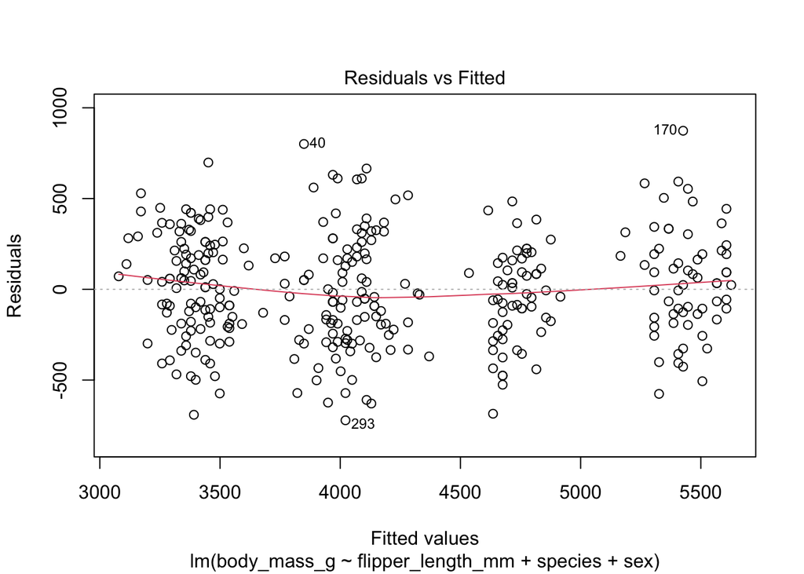

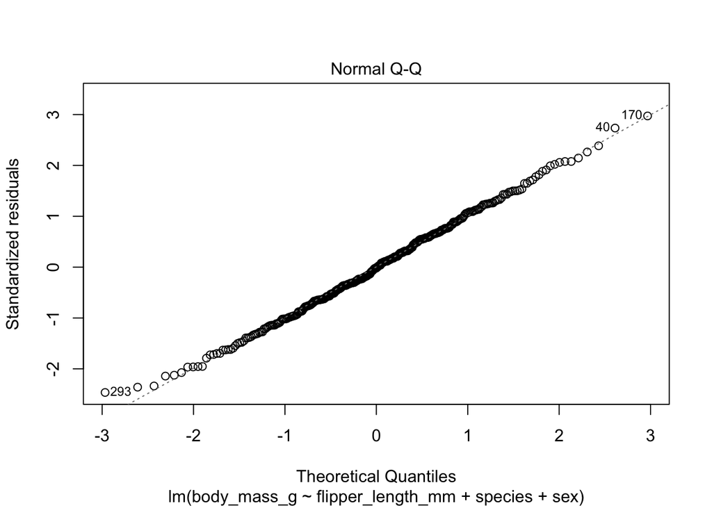

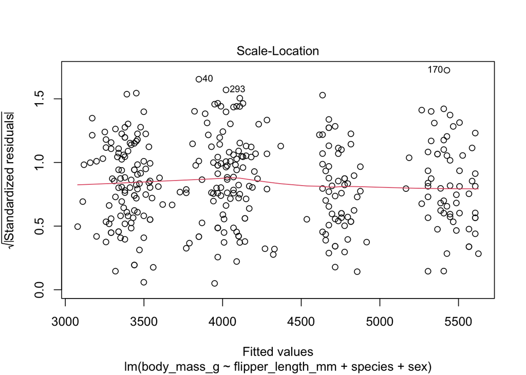

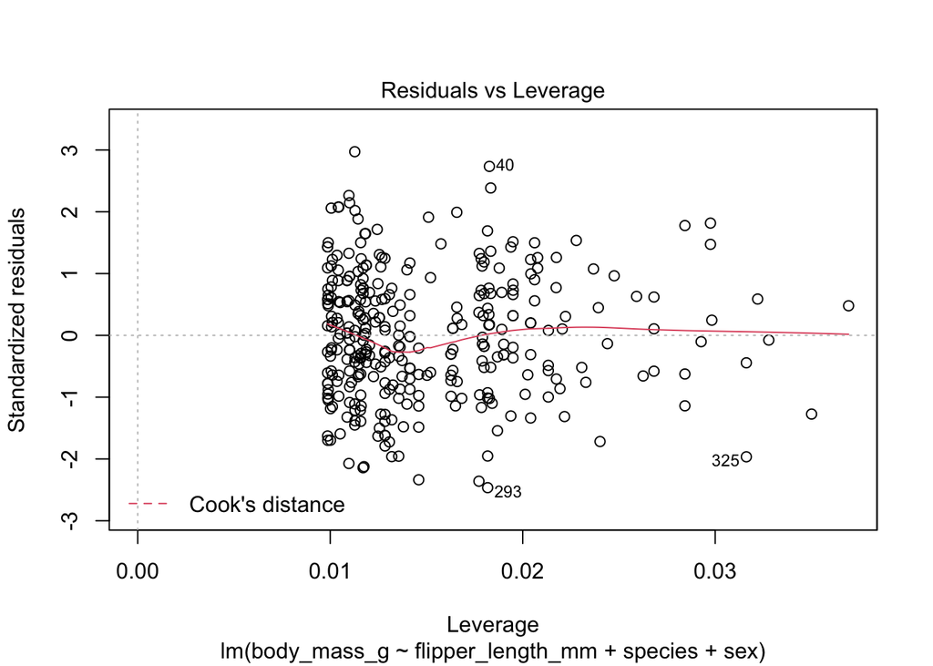

```r
plot(penguin_lm)
```

### 6. Communicate results of your model

Because there is a lot of information to include when reporting the results of multiple linear regressions, results are most often reported in a table. They are also often challenging to create manually, though `broom::tidy()` provides a good starting point.

There also exist a number of R packages to automate creating regression tables (for a great summary of different table-making packages from David Keyes, see: https://rfortherestofus.com/2019/11/how-to-make-beautiful-tables-in-r/).

Here are a couple of options:

#### a. A regular `kable` table

Starting from the tidy output and finalize manually (possibly with `kableExtra`, `gt`, or similar table-making packages). You’d want to further customize this (e.g. round to a reasonable number of significant figures, update ‘Term’ words, etc.).

*Note:* If you use this method, the caption should contain the overall model fil information (e.g. R<sup>2</sup> and model *p*-value).

```r
penguin_lm_tidy %>%
  kable(col.names = c("Term",
                      "Estimate",
                      "St Error",
                      "t-statistic",
                      "p-value")) %>%
  kable_styling(full_width = F)
```

| Term | Estimate | St Error | t-statistic | p-value |
| --- | --- | --- | --- | --- |
| (Intercept) | -365.81745 | 532.050313 | -0.6875618 | 0.4922147 |
| flipper_length_mm | 20.02492 | 2.845765 | 7.0367416 | 0.0000000 |
| speciesChinstrap | -87.63448 | 46.347250 | -1.8908237 | 0.0595290 |
| speciesGentoo | 836.26001 | 85.185449 | 9.8169350 | 0.0000000 |
| sexmale | 530.38109 | 37.810105 | 14.0274960 | 0.0000000 |

#### b. The `stargazer` package

Another option is the `stargazer` package, which creates a comprehensive regression table (including in html format).

Use the `stargazer()` function on your model name to produce the table. **NOTE:** to get this to appear correctly in your knitted html, you need to include two things:

- In the **code chunk header** add an option `results = "asis"` (i.e., the entire code chunk header should look like this: `{r, results = "asis"}`)
- Include the argument `type = "html"` within the `stargazer()` function as below (since the default is LaTeX)

```r
stargazer(penguin_lm, type = "html")
```

|  | *Dependent variable:* |
| --- | --- |
|  | body_mass_g |
| flipper_length_mm | 20.025*** |
|  | (2.846) |
| speciesChinstrap | -87.634* |
|  | (46.347) |
| speciesGentoo | 836.260*** |
|  | (85.185) |
| sexmale | 530.381*** |
|  | (37.810) |
| Constant | -365.817 |
|  | (532.050) |
| Observations | 333 |
| R<sup>2</sup> | 0.867 |
| Adjusted R<sup>2</sup> | 0.865 |
| Residual Std. Error | 295.565 (df = 328) |
| F Statistic | 534.024*** (df = 4; 328) |
| *Note:* | p<0.1; p<0.05; p<0.01 |

If you run the code in RStudio, it will look like a nightmare - that’s your table in HTML code! Once you knit, you should see it appear. You’d probably want to customize it a bit, but it’s a great starting point.

## END WEEK 8 LAB